# ExampleUseage

```r
library(casal, warn.conflicts = F)
library(stockassessmenthelper, warn.conflicts = F)
library(reshape2, warn.conflicts = F)
library(dplyr, warn.conflicts = F)
library(ggplot2, warn.conflicts = F)
library(purrr, warn.conflicts = F)
```

### Introduction

to see these vignettes type in `browseVignettes("stockassessmenthelper")` or `vignette("ExampleUseage")` or compile it yourself with knitr. Also hopefully all functions are documented so to query the inputs to a function use the `?` i.e. `?sim_pars`

## Selectivities

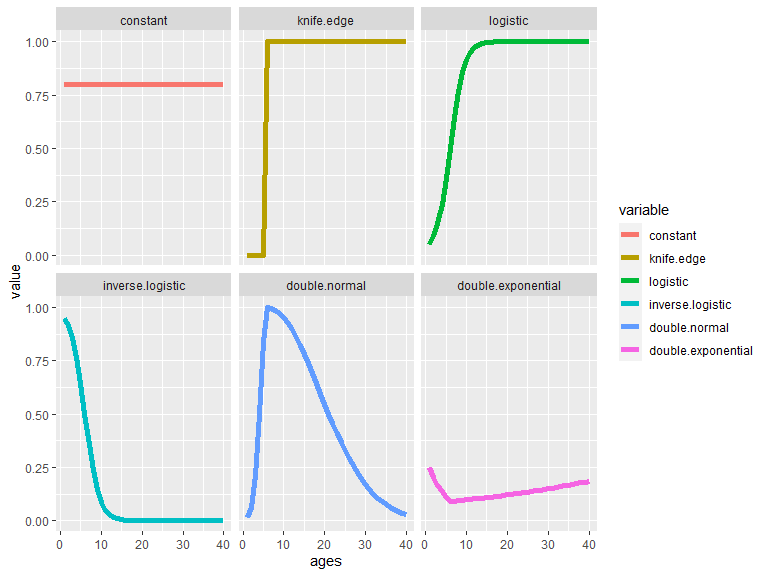

```r
ages = 1:40
# logistic
sel_data_frame = data.frame(ages = ages, constant = constant_sel(0.8, ages),
           "knife edge" = knife_sel(6, ages),
           logistic = logis_sel(ages, 6, 5),
           "inverse logistic" = inv_logis_sel(ages, 6, 5),
           "double normal" = d_norm_sel(ages, 6, 2, 15),
           "double exponential" = d_exp_sel(bins = ages, x_1 = 1, x_2 = 30, x_0 = 6, y_1 = 0.25, y_2 = 0.15, y_0 = 0.09))
sel_lng = melt(sel_data_frame, id.vars = "ages")
ggplot(sel_lng, aes(x = ages, y = value, group = variable, col = variable)) +
  geom_line(size = 2) +
  facet_wrap(~variable)
```

## Surplus Production models

## Growth

visualising growth functions and distributions of mean length at age. There are two growth functions available Von Bertalanffy `vonbert` and the generalised schnute growth function `schnute`.

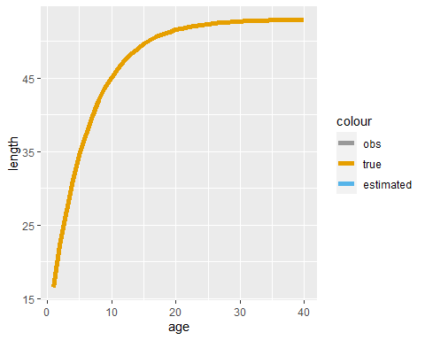

```r
col_legend = c("obs" = "#999999", "true" = "#E69F00",  "estimated" = "#56B4E9")
L_inf = 53
k = 0.17
t0 = -1.2
cv1 = 0.1
cv2 = 0.15
ages = 1:40
length_at_age = vonbert(ages, K = k, L_inf = L_inf, t0 = t0)
# cvs are by length
cvs_length = cv_by_length(cv1, cv2, length_at_age)
cvs_by_age = stretch(cv1, cv2, min(ages), max(ages))
growth_plot = ggplot(data = data.frame(age = ages, length = length_at_age), aes(x = age, y = length)) +
         geom_line(aes( col = "true"), size = 2) +
  scale_color_manual(values = col_legend)
growth_plot
```

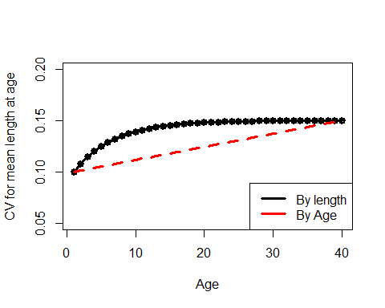

```r
## view the cv's
plot(ages, cvs_length, ylab = "CV for mean length at age", xlab = "Age", type = "o", lwd = 3, ylim = c(0.05, 0.2))
lines(ages, cvs_by_age, lwd = 3, lty = 2, col = "red")
legend('bottomright', col = c("black","red"), lwd = 3, legend = c("By length", "By Age"))
```

randomly generate synthetic data

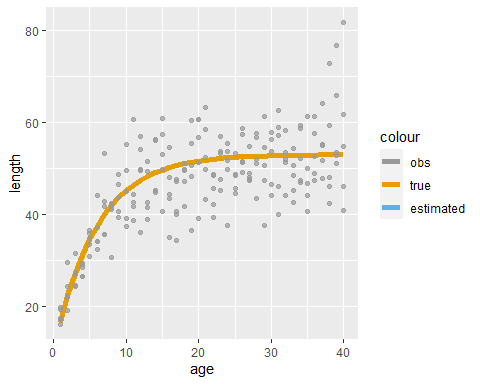

```r
n_samples_per_age = 5
age_length_data = NULL
for(a in 1:length(ages)) {
  lengths = r_lnorm(n_samples_per_age, length_at_age[a], cv = cvs_length[a])
  age_length_data = rbind(age_length_data, data.frame(age = a, length = lengths))
}
growth_plot_w_obs = growth_plot +
  geom_point(data = age_length_data, aes(col = "obs"), alpha = 0.7)
growth_plot_w_obs
```

```r
library(FSA) # a useful function for estimating growth
vbT <- vbFuns("typical")  ## set growth model type
# ?vbFuns for more growth curves. Not sure what error distribution this assumes?
start_ <- vbStarts(length~age,data = age_length_data,type="typical")  # start values
fit_ <- nls(length ~ vbT(age,Linf,K,t0),data = age_length_data, start = start_) # optimisation
pars_ = fit_$m$getPars() # get pars
pars_
fitted_line = vonbert(ages, K = pars_["K"], L_inf = pars_["Linf"], t0 = pars_["t0"])
growth_plot_w_obs +
  geom_line(data = data.frame(age = ages, length = fitted_line), aes(col = "estimated"), linetype = "dashed", size = 2)
```

[output not shown]

Another plot of length at age

```r
## concentrate on 3 ages for clarity
std_devs = log_sigma(cvs_length)
draws = 2000
ages_ndx = c(11:13)
these_ages = ages[ages_ndx]
dat = c(rnorm(draws, length_at_age[ages_ndx[1]], std_devs[ages_ndx[1]]),rnorm(draws, length_at_age[ages_ndx[2]], std_devs[ages_ndx[2]]),rnorm(draws, length_at_age[ages_ndx[3]], std_devs[ages_ndx[3]]))
dat = cbind(dat, c(rep(length_at_age[ages_ndx[1]], draws),rep(length_at_age[ages_ndx[2]], draws),rep(length_at_age[ages_ndx[3]], draws)))
dat = cbind(dat, c(runif(draws,these_ages[1] - 1,these_ages[1]), runif(draws,these_ages[1],these_ages[2]), runif(draws,these_ages[2],these_ages[3])))
cuts = cut(these_ages, breaks =c(min(these_ages)-1,these_ages))
dat = as.data.frame(dat)
dat$breaks = sort(rep(cuts, draws))
dat$age = sort(rep(these_ages, draws))
colnames(dat) = c("lengths","mean_length", "ages","breaks","age")

dens <- do.call(rbind, lapply(split(dat, dat$breaks), function(x) {
    xs <- seq(min(x$lengths) - 1, max(x$lengths) + 1, len=draws)
    norm = dnorm(xs, x$mean_length, 2)
    norm = x$age - norm /  (max(norm) + quantile(norm,0.5))
    res <- data.frame(y=xs, x=norm)
}))
dens$breaks = dat$breaks
ggplot(dat, aes(x = age, y = mean_length)) +
  xlim(min(these_ages) - 1, max(these_ages)) +
  geom_polygon(data=dens, aes(x, y, group = breaks),fill = "lightblue" ,alpha = 0.9) +
  geom_point(col = "black") +
  labs(x = "Age",y = "Length (cm)") +
  theme_bw()+
  theme(axis.text.x=element_text(size=15),axis.text.y=element_text(size=15),
        axis.title=element_text(size=15,face="bold"))
```

[output not shown]

## CASAL helpers

### Profiling Parameters

Assuming you have done a casal profile `casal -p` run the function `plot_CASAL_profile` will create a ggplot showing the effects of each objective contribution.

```r
# see what objective function components can be visualised?
data_path = system.file("extdata", package = "stockassessmenthelper")
possible_components = plot_CASAL_profile(file = "2021_profile_R0.casal", path = data_path,
                 profiled_param = "initialization.R0", objective_function_components = "all",
                 element = NULL, ask_for_obj_labels = T, likelihood_cut_off = 100,
                 custom_xlim = c(0,2e7))
possible_components
```

```
#>  [1] "BP_SPUE"                           "REC_CPUE"
#>  [3] "PS_AGE"                            "REC_AGE"
#>  [5] "ST_AGE"                            "prior_on_initialization.R0"
#>  [7] "prior_on_recruitment.YCS"          "prior_on_selectivity[Sel_PS].all"
#>  [9] "prior_on_selectivity[Sel_ST].all"  "prior_on_selectivity[Sel_REC].all"
#> [11] "prior_on_q_BP_SPUE"                "prior_on_q_REC_CPUE"
#> [13] "CatchMustBeTaken_PS"               "CatchMustBeTaken_ST"
#> [15] "CatchMustBeTaken_SN"               "CatchMustBeTaken_OTHER"
#> [17] "CatchMustBeTaken_REC"              "YCS_mean_1"
```

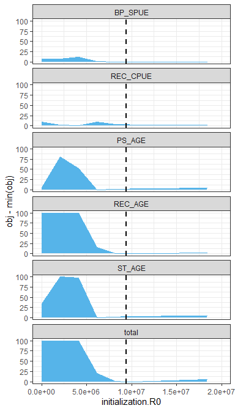

```r
# create a plot for a subset of these.
R0_profile = plot_CASAL_profile(file = "2021_profile_R0.casal", path = data_path,
                 profiled_param = "initialization.R0",
                 objective_function_components = c("BP_SPUE","REC_CPUE" ,"PS_AGE" ,"REC_AGE", "ST_AGE"),
                 element = NULL, ask_for_obj_labels = F, likelihood_cut_off = 100,
                 custom_xlim = c(0,2e7))
```

Another useful function for summarising a profiled run is the `extract.multiple.quantities`

### Simulating different starting values (Jittering)

To test the robustness of your assessment to the choice of starting values.

```r
diff_start_vals = sim_pars(dash_o_file_name = "MPD_dash_o_file.out", csl_path = data_path,
                 plus_minus_for_bounds = 0.1, n_pars = 10, index_of_pars_fixed = NULL)
diff_start_vals[1:5,1:5]
```

```
#>           [,1]      [,2]       [,3]       [,4]       [,5]
#> [1,] 0.3562710 0.3564855 0.08473709 0.07507288 0.09097183
#> [2,] 0.3587599 0.3293421 0.08422117 0.06672610 0.08491976
#> [3,] 0.3366141 0.3534641 0.08502258 0.07140556 0.07870519
#> [4,] 0.3670160 0.3451077 0.07651263 0.06276840 0.08585681
#> [5,] 0.3924974 0.3491079 0.08243766 0.07547154 0.08919958
```

this function will create a file called `sim_pars` in the `csl_path`, which can be used in the `-i` format for a CASAL model run.

### Pulling out states from a CASAL run

The following functions will pull out numbers at age from a CASAL model. `extract.step.AFs` and `extract.state`

### ReWeighting

An automated function for running Chris Francis’s reweighting Method TA1.8 approach on a CASAL model. Please read the details on this function it will **overwrite** the csl file. So it is adviced to save a copy of the original before running this code. Look at the function `?run_reweight`

## GGplot and DPlyr tips

Some useful functions to standardise numbers to proportions by levels of another factor i.e. year.

```r
df = data.frame(year = rep(c(2000, 2001), each = 30), X_val = rnorm(60, 34, 5))
## select columns that start with 'X'
sub_df = df %>% dplyr::select(starts_with("X"))
## standardise
temp_df = df %>%
  group_by(year) %>%
  mutate(stand_x_val = across(X_val, .fn = function(x){x/sum(x)}))
## alternative
temp_df_alt = df %>%
  group_by(year) %>%
  mutate(stand_x_val = across(X_val, .fn = list(~ ./sum(.))))
## check totals sum = 1
temp_df %>% group_by(year) %>% summarise(totals = sum(stand_x_val))
```

```
#> # A tibble: 2 x 2
#>    year totals
#>   <dbl>  <dbl>
#> 1  2000      1
#> 2  2001      1
```

```r
temp_df_alt %>% group_by(year) %>% summarise(totals = sum(stand_x_val))
```

```
#> # A tibble: 2 x 2
#>    year totals
#>   <dbl>  <dbl>
#> 1  2000      1
#> 2  2001      1
```

A useful function for plotting SSB quantiles.

```r
## Set quantile range
p <- c(0.025, 0.5, 0.975)
labs = c("low", "mid", "upp") ## set labels
p_funs <- map(p, ~partial(quantile, probs = .x, na.rm = TRUE)) %>%
  set_names(nm = labs)
p_funs
```

```
#> $low
#> <partialised>
#> function (...)
#> quantile(probs = .x, na.rm = TRUE, ...)
#>
#> $mid
#> <partialised>
#> function (...)
#> quantile(probs = .x, na.rm = TRUE, ...)
#>
#> $upp
#> <partialised>
#> function (...)
#> quantile(probs = .x, na.rm = TRUE, ...)
## get data set
```

```r
ssb_df = data.frame(year = rep(c(2000, 2001, 2002), each = 300),
                    SSB = c(rnorm(300, 2000, 200), rnorm(300, 2500, 200), rnorm(300, 1500, 200)))
## run function over data set
quantile_ssb_df = ssb_df %>%
  group_by(year) %>%
  summarize_at(vars(SSB), funs(!!!p_funs))
```

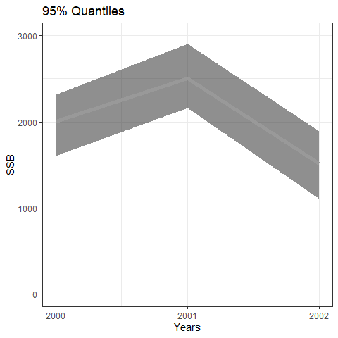

```r
quant_ssb_plot = ggplot(quantile_ssb_df, aes(x = year, linetype = "dashed")) +
  geom_ribbon(aes(ymax  = low, ymin = upp, alpha = 0.5), lwd=0) +
  theme_bw() +
  geom_line(aes(y = mid), size =2, col = "grey60") +
  xlab("Years") +
  ylab("SSB") +
  ylim(0, 3000) +
  guides(alpha = 'none', linetype = "none") +
  ggtitle("95% Quantiles") +
  scale_x_continuous(breaks=c(2000, 2001, 2002))
quant_ssb_plot
```